# Part B - Linear Regression Workflow

# Assess the Model Performance

## Plot the Model

Now that we have determined the appropriate model, we can plot it over all of the data:

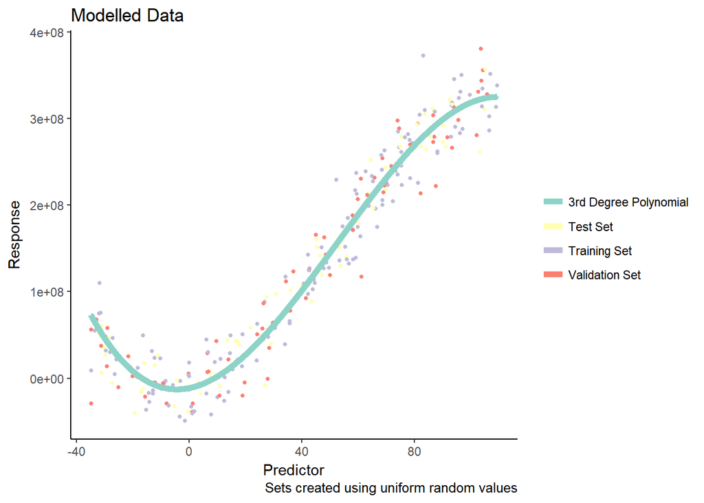

```r
##Specify the Correct Model
correct.mod.degree <- error.df[error.df$`Validation Error`==min(
                                    error.df$`Validation Error`),]$Order
correct.mod        <- train.mod.list[[correct.mod.degree]]

##Create a sufficiently large dataframe of predictions
  #such that the model is smooth

correct.mod.df <- data.frame(input = seq(from = min(all.df$input),
                                   to = max(all.df$input), length.out = 10^4))
  correct.mod.df$mod_correct <- predict(object = correct.mod,
                                        newdata = correct.mod.df)

##Plot the predictions over the data
  all.plot +
    geom_line(data = correct.mod.df, size = 2,
              alpha = 1,
              aes(y = mod_correct,
                                                      col = "purple")) +
    scale_color_brewer(palette="Set3",
                       labels = c("3rd Degree Polynomial",
                                  "Test Set",
                                  "Training Set",
                                  "Validation Set")) +
    guides(col = guide_legend(title = NULL)) +
    labs(title = "Modelled Data", subtitle = NULL)
```

## Consider the Performance Metrics

The RMSE value of the model, relative to the test set is:

```r
rmse.test <- rmse(test.df, correct.mod)
sd.test   <- sd(test.df$output)
ratio     <- rmse(test.df, correct.mod)/sd(test.df$output)

performance <- data.frame(RMSE = rmse.test, SD = sd.test, Ratio = ratio)
print(performance)
```

```
##       RMSE        SD     Ratio
## 1 23085544 117559998 0.1963724
```

The rmse is a measure of the expected error from data point to model value, the rmse is 20% the size of the standard deviation, hence the model can predict on the test set with greater accuracy than merely taking the average output value

### Assess the Residuals

If the model is descriptive of the data (not merely predictive), the error observed between the model and the data should be normally distributed, white noise:

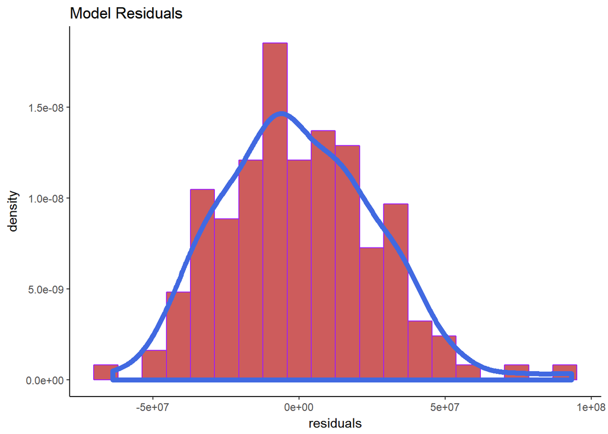

```r
ggplot(data = data.frame(residuals = correct.mod$residuals), aes(residuals)) +
  geom_histogram(bins = 20, aes(y = ..density..), fill = 'indianred', col = 'purple') +
  geom_density(col = "Royalblue", lwd = 2) +
  theme_classic() +
  labs(title = "Model Residuals")
```

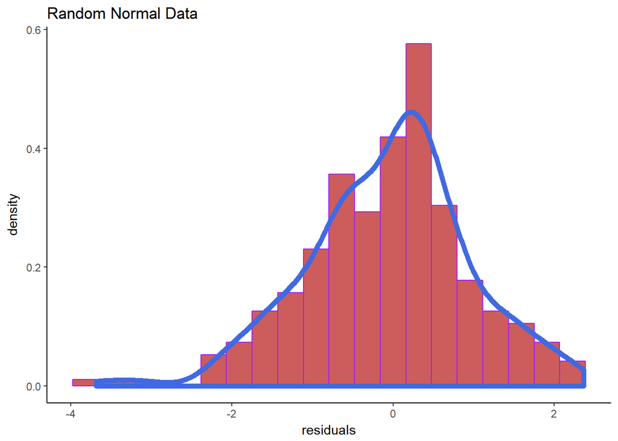

```r
ggplot(data = data.frame(residuals = rnorm(300)), aes(residuals)) +
  geom_histogram(bins = 20, aes(y = ..density..), fill = 'indianred', col = 'purple') +
  geom_density(col = "Royalblue", lwd = 2) +
  theme_classic() +
  labs(title = "Random Normal Data")
```

It can be seen that the residuals are sufficiently normally distributed, and sufficiently centred about 0, to accespt that this is an appopriate model for the data (i.e. this might predict but also describe the data with added noise).